# RL-RNA dataset SA

Importación del dataset

```r
datasetSA <- read.csv("./datasetSA.csv")
head(datasetSA)
```

|  | V1 | V2 | V3 | V4 | V5 | V6 | V7 | V8 | V9 | Class |
| --- | --- | --- | --- | --- | --- | --- | --- | --- | --- | --- |
| 1 | 160 | 12.00 | 5.73 | 23.11 | 1 | 49 | 25.30 | 97.20 | 52 | 2 |
| 2 | 144 | 0.01 | 4.41 | 28.61 | 2 | 55 | 28.87 | 2.06 | 63 | 2 |
| 3 | 118 | 0.08 | 3.48 | 32.28 | 1 | 52 | 29.14 | 3.81 | 46 | 1 |
| 4 | 170 | 7.50 | 6.41 | 38.03 | 1 | 51 | 31.99 | 24.26 | 58 | 2 |
| 5 | 134 | 13.60 | 3.50 | 27.78 | 1 | 60 | 25.99 | 57.34 | 49 | 2 |
| 6 | 132 | 6.20 | 6.47 | 36.21 | 1 | 62 | 30.77 | 14.14 | 45 | 1 |

Etiquetado de columnas

```r
colnames(datasetSA) <- c('presionArterialSistolica','tabacoAcumulado','LDL','adiposidad','historialFamiliar','compTip A','obesidad','consumoAlcohol','edad','enfCard')
head(datasetSA)
```

|  | presionArterialSistolica | tabacoAcumulado | LDL | adiposidad | historialFamiliar | compTip A | obesidad | consumoAlcohol | edad | enfCard |
| --- | --- | --- | --- | --- | --- | --- | --- | --- | --- | --- |
| 1 | 160 | 12.00 | 5.73 | 23.11 | 1 | 49 | 25.30 | 97.20 | 52 | 2 |
| 2 | 144 | 0.01 | 4.41 | 28.61 | 2 | 55 | 28.87 | 2.06 | 63 | 2 |
| 3 | 118 | 0.08 | 3.48 | 32.28 | 1 | 52 | 29.14 | 3.81 | 46 | 1 |
| 4 | 170 | 7.50 | 6.41 | 38.03 | 1 | 51 | 31.99 | 24.26 | 58 | 2 |
| 5 | 134 | 13.60 | 3.50 | 27.78 | 1 | 60 | 25.99 | 57.34 | 49 | 2 |
| 6 | 132 | 6.20 | 6.47 | 36.21 | 1 | 62 | 30.77 | 14.14 | 45 | 1 |

Para ver un resumen de cómo se encuentra el dataset actualmente:

```r
str(datasetSA)
```

```
'data.frame':   462 obs. of  10 variables:
 $ presionArterialSistolica: int  160 144 118 170 134 132 142 114 114 132 ...
 $ tabacoAcumulado         : num  12 0.01 0.08 7.5 13.6 6.2 4.05 4.08 0 0 ...
 $ LDL                     : num  5.73 4.41 3.48 6.41 3.5 6.47 3.38 4.59 3.83 5.8 ...
 $ adiposidad              : num  23.1 28.6 32.3 38 27.8 ...
 $ historialFamiliar       : int  1 2 1 1 1 1 2 1 1 1 ...
 $ compTip A               : int  49 55 52 51 60 62 59 62 49 69 ...
 $ obesidad                : num  25.3 28.9 29.1 32 26 ...
 $ consumoAlcohol          : num  97.2 2.06 3.81 24.26 57.34 ...
 $ edad                    : int  52 63 46 58 49 45 38 58 29 53 ...
 $ enfCard                 : int  2 2 1 2 2 1 1 2 1 2 ...
```

Para transformar los 2/1 a 1/0:

```r
datasetSA$historialFamiliar <- datasetSA$historialFamiliar - 1
datasetSA$enfCard <- datasetSA$enfCard -1
```

Para escalar la presión arterial sistólica de 0 a 100:

```r
datasetSA$presionArterialSistolica<- scales::rescale(datasetSA$presionArterialSistolica, to=c(0,100))
```

Ahora un par de factores a columnas que nos sirven para contar las variables binarias.

```r
head(datasetSA)
```

|  | presionArterialSistolica | tabacoAcumulado | LDL | adiposidad | historialFamiliar | compTip A | obesidad | consumoAlcohol | edad | enfCard |
| --- | --- | --- | --- | --- | --- | --- | --- | --- | --- | --- |
| 1 | 50.42735 | 12.00 | 5.73 | 23.11 | 0 | 49 | 25.30 | 97.20 | 52 | 1 |
| 2 | 36.75214 | 0.01 | 4.41 | 28.61 | 1 | 55 | 28.87 | 2.06 | 63 | 1 |
| 3 | 14.52991 | 0.08 | 3.48 | 32.28 | 0 | 52 | 29.14 | 3.81 | 46 | 0 |
| 4 | 58.97436 | 7.50 | 6.41 | 38.03 | 0 | 51 | 31.99 | 24.26 | 58 | 1 |
| 5 | 28.20513 | 13.60 | 3.50 | 27.78 | 0 | 60 | 25.99 | 57.34 | 49 | 1 |
| 6 | 26.49573 | 6.20 | 6.47 | 36.21 | 0 | 62 | 30.77 | 14.14 | 45 | 0 |

```r
sum(is.na(datasetSA))
```

```
[1] 0
```

```r
datasetSA$historialFamiliar<- as.factor(datasetSA$historialFamiliar)
levels(datasetSA$historialFamiliar)[levels(datasetSA$historialFamiliar)==0] <- "No tiene historial familiar"
levels(datasetSA$historialFamiliar)[levels(datasetSA$historialFamiliar)==1] <- "Tiene historial familiar"

datasetSA$enfCard<-as.factor(datasetSA$enfCard)
levels(datasetSA$enfCard)[levels(datasetSA$enfCard)==0] <- "No enfermo"
levels(datasetSA$enfCard)[levels(datasetSA$enfCard)==1]<- "Enfermo"

datasetSA$obesidad[datasetSA$obesidad < 30] <- 0
datasetSA$obesidad[datasetSA$obesidad >= 30] <- 1

datasetSA$obesidad<-as.factor(datasetSA$obesidad)
levels(datasetSA$obesidad)[levels(datasetSA$obesidad)==0] <- "No obeso"
levels(datasetSA$obesidad)[levels(datasetSA$obesidad)==1] <- "Obeso"


str(datasetSA)
```

```
'data.frame':   462 obs. of  10 variables:
 $ presionArterialSistolica: num  50.4 36.8 14.5 59 28.2 ...
 $ tabacoAcumulado         : num  12 0.01 0.08 7.5 13.6 6.2 4.05 4.08 0 0 ...
 $ LDL                     : num  5.73 4.41 3.48 6.41 3.5 6.47 3.38 4.59 3.83 5.8 ...
 $ adiposidad              : num  23.1 28.6 32.3 38 27.8 ...
 $ historialFamiliar       : Factor w/ 2 levels "No tiene historial familiar",..: 1 2 1 1 1 1 2 1 1 1 ...
 $ compTip A               : int  49 55 52 51 60 62 59 62 49 69 ...
 $ obesidad                : Factor w/ 2 levels "No obeso","Obeso": 1 1 1 2 1 2 1 1 1 2 ...
 $ consumoAlcohol          : num  97.2 2.06 3.81 24.26 57.34 ...
 $ edad                    : int  52 63 46 58 49 45 38 58 29 53 ...
 $ enfCard                 : Factor w/ 2 levels "No enfermo","Enfermo": 2 2 1 2 2 1 1 2 1 2 ...
```

```r
summary(datasetSA)
```

```
 presionArterialSistolica tabacoAcumulado        LDL           adiposidad                      historialFamiliar   compTip A
 Min.   :  0.00           Min.   : 0.0000   Min.   : 0.980   Min.   : 6.74   No tiene historial familiar:192     Min.   :13.0
 1st Qu.: 19.66           1st Qu.: 0.0525   1st Qu.: 3.283   1st Qu.:19.77   Tiene historial familiar   :270     1st Qu.:47.0
 Median : 28.21           Median : 2.0000   Median : 4.340   Median :26.11                                       Median :53.0
 Mean   : 31.90           Mean   : 3.6356   Mean   : 4.740   Mean   :25.41                                       Mean   :53.1
 3rd Qu.: 40.17           3rd Qu.: 5.5000   3rd Qu.: 5.790   3rd Qu.:31.23                                       3rd Qu.:60.0
 Max.   :100.00           Max.   :31.2000   Max.   :15.330   Max.   :42.49                                       Max.   :78.0
     obesidad   consumoAlcohol        edad             enfCard
 No obeso:389   Min.   :  0.00   Min.   :15.00   No enfermo:302
 Obeso   : 73   1st Qu.:  0.51   1st Qu.:31.00   Enfermo   :160
                Median :  7.51   Median :45.00
                Mean   : 17.04   Mean   :42.82
                3rd Qu.: 23.89   3rd Qu.:55.00
                Max.   :147.19   Max.   :64.00
```

Siguiente paso: visualizaciones. 1 - Número total de observaciones de gente no enferma y gente con enfermedad cardíaca.

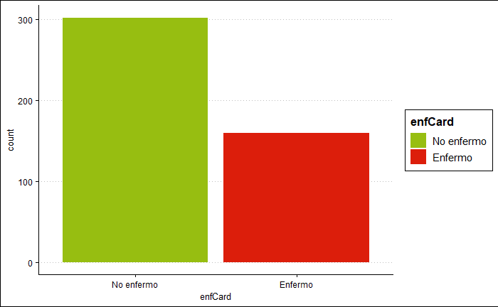

```r
ggplot(datasetSA,aes(enfCard, fill=enfCard)) +
geom_bar(stat="count") + theme_clean() +
scale_fill_manual(values=c("#97BE11","#DC1E0B"))
```

2 - Enfermedad cardíaca entre aquellos con historial familiar

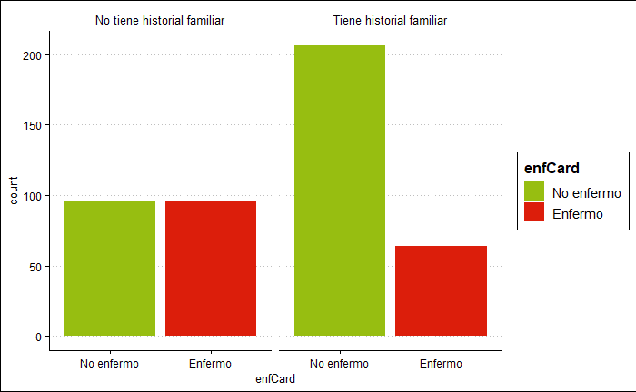

```r
ggplot(datasetSA,aes(enfCard, fill=enfCard)) +
geom_bar(stat="count")+ facet_wrap(~historialFamiliar, ncol=2,scale="fixed")+ theme_clean() +
scale_fill_manual(values=c("#97BE11","#DC1E0B"))
```

3 - Enfermedad cardíaca entre aquellos con obesidad

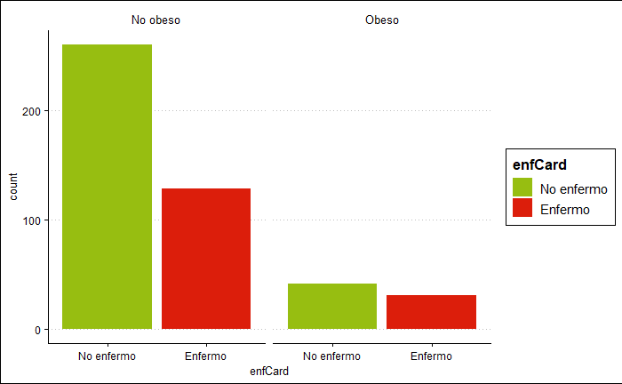

```r
ggplot(datasetSA,aes(enfCard, fill=enfCard)) +
geom_bar(stat="count")+ facet_wrap(~obesidad, ncol=2,scale="fixed")+ theme_clean() +
scale_fill_manual(values=c("#97BE11","#DC1E0B"))

ggsave("SA-obesidad-vs-enfCard.png")
```

4- Diferencias en presión arterial sistólica entre pacientes enfermos y no enfermos.

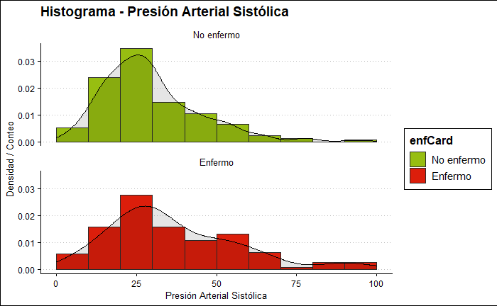

```r
ggplot(datasetSA,aes(presionArterialSistolica, fill=enfCard)) +
geom_histogram(aes(y=..density..),breaks=seq(0, 100, by=10), color="grey17") +
geom_density(alpha=.1, fill="black") +
facet_wrap(~enfCard, ncol=1,scale="fixed") +
theme_clean() +
scale_fill_manual(values=c("#97BE11","#DC1E0B")) +
xlab("Presión Arterial Sistólica") +
ylab("Densidad / Conteo") +
ggtitle("Histograma - Presión Arterial Sistólica")
ggsave("SA-hist-presionArterialSistolica.png")
```

5- Presencia de enfermedad cardíaca según edad

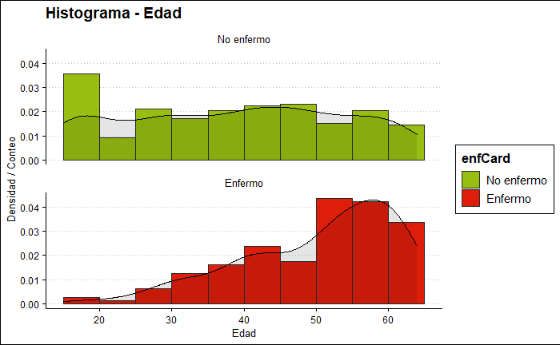

```r
ggplot(datasetSA,aes(edad, fill=enfCard)) +
geom_histogram(aes(y=..density..),breaks=seq(15, 65, by=5), color="grey17") +
geom_density(alpha=.1, fill="black")+ facet_wrap(~enfCard, ncol=1,scale="fixed") +
theme_clean() + scale_fill_manual(values=c("#97BE11","#DC1E0B"))+ xlab("Edad") +
ylab("Densidad / Conteo") +
ggtitle("Histograma - Edad")
ggsave("SA-hist-edad.png")
```

6 - Diagrama de caja (Edad)

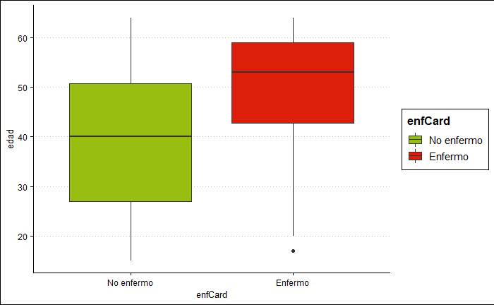

```r
ggplot(datasetSA,aes(x=enfCard, y=edad, fill=enfCard)) +
geom_boxplot() +
theme_clean() +
scale_fill_manual(values=c("#97BE11","#DC1E0B"))
ggsave("SA-boxplot-edad.png")
```

7 - Colesterol vs enfCard

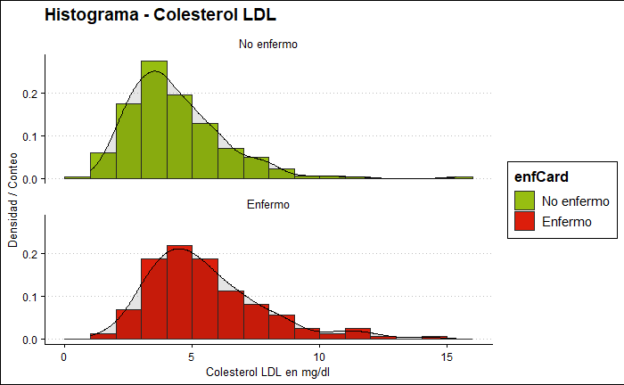

```r
ggplot(datasetSA,aes(LDL, fill=enfCard)) +
geom_histogram(aes(y=..density..),breaks=seq(0, 16, by=1), color="grey17") +
geom_density(alpha=.1, fill="black") +
facet_wrap(~enfCard, ncol=1,scale="fixed") +
theme_clean() +
scale_fill_manual(values=c("#97BE11","#DC1E0B")) +
xlab("Colesterol LDL en mg/dl") +
ylab("Densidad / Conteo") +
ggtitle("Histograma - Colesterol LDL")
ggsave("SA-hist-LDL.png")
```

8 - Adiposidad vs enfCard

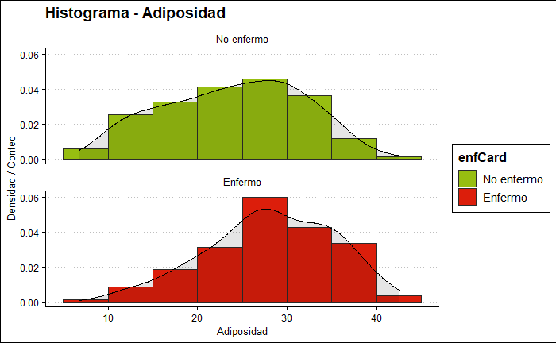

```r
ggplot(datasetSA,aes(adiposidad, fill=enfCard)) +
geom_histogram(aes(y=..density..),breaks=seq(5, 45, by=5), color="grey17") +
geom_density(alpha=.1, fill="black") +
facet_wrap(~enfCard, ncol=1,scale="fixed") +
theme_clean() +
scale_fill_manual(values=c("#97BE11","#DC1E0B")) +
xlab("Adiposidad") +
ylab("Densidad / Conteo") +
ggtitle("Histograma - Adiposidad")
ggsave("SA-hist-adiposidad.png")
```

9 - Tabaco acumulado vs enfCard

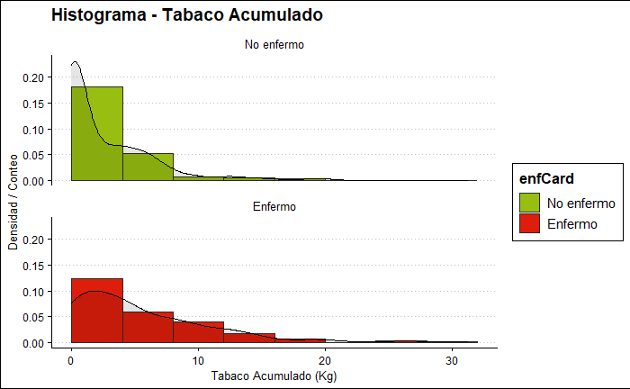

```r
ggplot(datasetSA,aes(tabacoAcumulado, fill=enfCard)) +
geom_histogram(aes(y=..density..),breaks=seq(0, 32, by=4), color="grey17") +
geom_density(alpha=.1, fill="black")+ facet_wrap(~enfCard, ncol=1,scale="fixed") +
theme_clean() + scale_fill_manual(values=c("#97BE11","#DC1E0B"))+ xlab("Tabaco Acumulado (Kg)") +
ylab("Densidad / Conteo") +
ggtitle("Histograma - Tabaco Acumulado")
ggsave("SA-hist-tabacoAcumulado.png")
```

Sacaremos un dataframe con las variables significativas

```r
d <- datasetSA[,c(2,3,4,7,9,10)]
summary(d)
```

```
 tabacoAcumulado        LDL           adiposidad        obesidad        edad             enfCard
 Min.   : 0.0000   Min.   : 0.980   Min.   : 6.74   No obeso:389   Min.   :15.00   No enfermo:302
 1st Qu.: 0.0525   1st Qu.: 3.283   1st Qu.:19.77   Obeso   : 73   1st Qu.:31.00   Enfermo   :160
 Median : 2.0000   Median : 4.340   Median :26.11                  Median :45.00
 Mean   : 3.6356   Mean   : 4.740   Mean   :25.41                  Mean   :42.82
 3rd Qu.: 5.5000   3rd Qu.: 5.790   3rd Qu.:31.23                  3rd Qu.:55.00
 Max.   :31.2000   Max.   :15.330   Max.   :42.49                  Max.   :64.00
```

Iniciamos la regresión logística

```r
log <- glm(enfCard~., data=d, family=binomial)
summary(log)
```

```
Call:
glm(formula = enfCard ~ ., family = binomial, data = d)

Deviance Residuals:
    Min       1Q   Median       3Q      Max
-2.0319  -0.8519  -0.4980   1.0258   2.3644

Coefficients:
                Estimate Std. Error z value Pr(>|z|)
(Intercept)     -3.92418    0.52141  -7.526 5.23e-14 ***
tabacoAcumulado  0.07664    0.02562   2.991  0.00278 **
LDL              0.19780    0.05822   3.398  0.00068 ***
adiposidad      -0.01329    0.02198  -0.605  0.54551
obesidadObeso    0.15087    0.33970   0.444  0.65695
edad             0.05180    0.01094   4.736 2.18e-06 ***
---
Signif. codes:  0 ‘***’ 0.001 ‘**’ 0.01 ‘*’ 0.05 ‘.’ 0.1 ‘ ’ 1

(Dispersion parameter for binomial family taken to be 1)

    Null deviance: 596.11  on 461  degrees of freedom
Residual deviance: 502.44  on 456  degrees of freedom
AIC: 514.44

Number of Fisher Scoring iterations: 4
```

Pruebas indican que a mayor edad y tabaco acumulado, mayor la posibilidad de enfermedad cardíaca.

```r
log.df <- tidy(log)
```

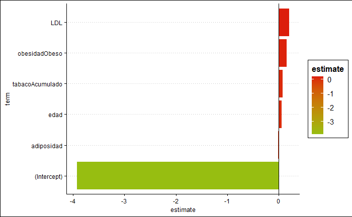

```r
log.df %>%
mutate(term=reorder(term,estimate)) %>%
ggplot( aes(term,estimate, fill=estimate)) +
geom_bar(stat="identity") +
scale_fill_gradient(low = "#97BE11",high = "#DC1E0B") +
theme_clean() +
geom_hline(yintercept=0) +
coord_flip()

ggsave("SA-variables-orden-imp.png")
```

```r
data<-d
set.seed(1237)
train <- sample(nrow(data), .8*nrow(data), replace = FALSE)
TrainingSet <- data[train,]
ValidSet <- data[-train,]

#Parámetros
fitControl <- trainControl(method = "repeatedcv",
                            number = 10,
                            repeats = 10,
                            classProbs = TRUE,
                            summaryFunction = twoClassSummary)

TrainingSet$enfCard<-make.names(TrainingSet$enfCard)
set.seed(142)
TrainingSet$enfCard<-as.factor(TrainingSet$enfCard)


gbm.ada.1 <- caret::train(enfCard ~ .,
                          data = TrainingSet ,
                          method = "glm",
                          trControl = fitControl,
                          metric="ROC")

gbm.ada.1
```

```
Generalized Linear Model

369 samples
  5 predictor
  2 classes: 'Enfermo', 'No.enfermo'

No pre-processing
Resampling: Cross-Validated (10 fold, repeated 10 times)
Summary of sample sizes: 333, 332, 331, 332, 332, 333, ...
Resampling results:

  ROC        Sens       Spec
  0.7469215  0.3979487  0.8547667
```

```r
varImp(gbm.ada.1)
```

```
glm variable importance
```

|  | Overall |
| --- | --- |
| edad | 100.00000 |
| LDL | 80.49304 |
| tabacoAcumulado | 67.08774 |
| obesidadObeso | 12.37103 |
| adiposidad | 0.00000 |

```r
res
```

```
Confusion Matrix and Statistics

            Reference
Prediction   No enfermo Enfermo
  No enfermo         49      25
  Enfermo             6      13

               Accuracy : 0.6667
                 95% CI : (0.5613, 0.7611)
    No Information Rate : 0.5914
    P-Value [Acc > NIR] : 0.084079

                  Kappa : 0.2525

 Mcnemar's Test P-Value : 0.001225

            Sensitivity : 0.3421
            Specificity : 0.8909
         Pos Pred Value : 0.6842
         Neg Pred Value : 0.6622
             Prevalence : 0.4086
         Detection Rate : 0.1398
   Detection Prevalence : 0.2043
      Balanced Accuracy : 0.6165

       'Positive' Class : Enfermo
```

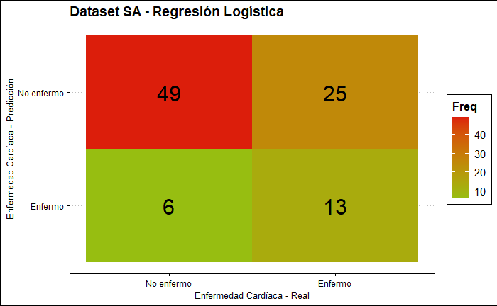

```r
ggplot(data = t.df, aes(x = Var2, y = pred, label=Freq)) +
geom_tile(aes(fill = Freq)) +
scale_fill_gradient(low="#97BE11",high="#DC1E0B") +
theme_clean() +
xlab("Enfermedad Cardíaca - Real") +
ylab("Enfermedad Cardíaca - Predicción") +
geom_text(size=8) +
ggtitle("Dataset SA - Regresión Logística")
ggsave("SA-RL-cf-matrix.png")
```

Listo nuestro trabajo con la regresión logística. Ahora, a por la red neural.

```r
fitControl <- trainControl(method = "repeatedcv",
number = 10,
repeats = 10,
classProbs = TRUE,
summaryFunction = twoClassSummary)
gbm.ada.1 <- caret::train(enfCard ~ .,
data = TrainingSet ,
method = "nnet",
trControl = fitControl,
metric="ROC")
```

```r
gbm.ada.1
```

```
Neural Network

369 samples
  5 predictor
  2 classes: 'Enfermo', 'No.enfermo'

No pre-processing
Resampling: Cross-Validated (10 fold, repeated 10 times)
Summary of sample sizes: 332, 331, 333, 332, 332, 332, ...
Resampling results across tuning parameters:

  size  decay  ROC        Sens        Spec
  1     0e+00  0.5491595  0.08653846  0.9534000
  1     1e-04  0.5347869  0.07339744  0.9738167
  1     1e-01  0.5819627  0.26891026  0.8910167
  3     0e+00  0.6248771  0.20653846  0.9247000
  3     1e-04  0.6047169  0.18775641  0.9224000
  3     1e-01  0.7128198  0.38025641  0.8470167
  5     0e+00  0.6392873  0.27910256  0.8681833
  5     1e-04  0.6860879  0.32000000  0.8659667
  5     1e-01  0.7022251  0.37967949  0.8300167

ROC was used to select the optimal model using the largest value.
The final values used for the model were size = 3 and decay = 0.1.
```

```r
varImp(gbm.ada.1)
```

```
nnet variable importance
```

|  | Overall |
| --- | --- |
| obesidadObeso | 100.0000000 |
| tabacoAcumulado | 49.4168111 |
| LDL | 22.5301541 |
| adiposidad | 0.9714213 |
| edad | 0.0000000 |

```r
pred <- predict(gbm.ada.1,ValidSet)
levels(pred)[2] <- "No enfermo"
t<-table(pred, ValidSet$enfCard)
t.df<-as.data.frame(t)
res<-caret::confusionMatrix(pred, ValidSet$enfCard, positive = "Enfermo")
```

```
Levels are not in the same order for reference and data. Refactoring data to match.
```

```r
res
```

```
Confusion Matrix and Statistics

            Reference
Prediction   No enfermo Enfermo
  No enfermo         46      25
  Enfermo             9      13

               Accuracy : 0.6344
                 95% CI : (0.5281, 0.7319)
    No Information Rate : 0.5914
    P-Value [Acc > NIR] : 0.2312

                  Kappa : 0.1909

 Mcnemar's Test P-Value : 0.0101

            Sensitivity : 0.3421
            Specificity : 0.8364
         Pos Pred Value : 0.5909
         Neg Pred Value : 0.6479
             Prevalence : 0.4086
         Detection Rate : 0.1398
   Detection Prevalence : 0.2366
      Balanced Accuracy : 0.5892

       'Positive' Class : Enfermo
```

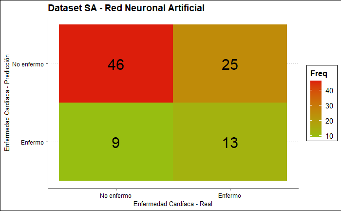

```r
ggplot(data = t.df, aes(x = Var2, y = pred, label=Freq)) +
geom_tile(aes(fill = Freq)) +
scale_fill_gradient(low="#97BE11",high="#DC1E0B") +
theme_clean() +
xlab("Enfermedad Cardíaca - Real") +
ylab("Enfermedad Cardíaca - Predicción") +
geom_text(size=8) +
ggtitle("Dataset SA - Red Neuronal Artificial")
ggsave("SA-RNA-cf-matrix.png")
```